# R Notebook

[figure not shown]

## I. Background

#### It is undeniable that love plays an essential role in our life. Although it can not be seen or touched, it is discussed in songs, movies, novels, in every corner of life. The nature of love has been a mainstay in philosophy since the time of the Ancient Greeks. This report explores what philosophers from different periods and schools say about love.

#### The dataset used in this report is downloaded from https://www.kaggle.com/kouroshalizadeh/history-of-philosophy, which is a corpus of over 360,000 sentences from over 50 texts spanning 13 schools of philosophy. You can find more information about the Philosophy Data Project on http://philosophydata.com/index.html

This report was prepared with the following environmental settings.

```r
print(R.version)
```

```
##                _
## platform       x86_64-w64-mingw32
## arch           x86_64
## os             mingw32
## system         x86_64, mingw32
## status
## major          4
## minor          0.3
## year           2020
## month          10
## day            10
## svn rev        79318
## language       R
## version.string R version 4.0.3 (2020-10-10)
## nickname       Bunny-Wunnies Freak Out
```

## II. Data preparation and exploration

I started from loading and processing the raw data ‘philosophy_data.csv’ saved in data file. Since the report focuses on the topic about love, the data was first cleaned by picking out the sentences that contain the key words "love" and adding a new column that sorts the data into the corresponding period based on the original publication date. And then, I divided the data into several subsets based on different periods and schools. The final dataset used for subsetting is saved in output file.

### 1. Group by period

The history of philosophy can be divided into four periods:  
** + Ancient philosophy (600 B.C.E.–1000 C.E.) **  
** + Medieval philosophy (1000 C.E.–1500 C.E.)**  
** + Modern philosophy (1500 C.E.–1900 C.E)**  
** + Contemporary philosophy (1900 C.E. - present)**  
It turns out that our dataset has a gap and does not have any data that's within the medieval period.

### 2. Group by school

There are 13 schools in the dataset:

```
## # A tibble: 13 x 1
##    value
##    <chr>
##  1 plato
##  2 aristotle
##  3 empiricism
##  4 rationalism
##  5 analytic
##  6 continental
##  7 phenomenology
##  8 german_idealism
##  9 communism
## 10 capitalism
## 11 stoicism
## 12 nietzsche
## 13 feminism
```

Since there are too many schools in the dataset, I select 5 of them as representatives based on the number of observations each school talked about love, which are:  
**Plato, Aristotle, Rationalism, Nietzsche, and Feminism Philosophy.**  
The following analysis will only be based on these chosen schools.

### 3. Data mining

I define a function called clean() to remove stopwords, create a tidy version of texts, count frequency of each word, and plot word cloud for each subsets.

```r
#define the stop words
stopword<-as.character(stop_words$word)

#define a function for text mining and visualization
clean<-function(sub){
  sub<-as.data.frame(sub)
  title=paste0(unique(sub$school),' Word Frequency Chart')
  corpus<-VCorpus(VectorSource(sub$sentence_lowered))%>%
    tm_map(removeWords, stopword)%>%
    tm_map(removePunctuation)%>%
    tm_map(removeNumbers)%>%
    tm_map(removeWords, character(0))%>%
    tm_map(stripWhitespace)

  sub.tidy=tidy(TermDocumentMatrix(corpus))
  overall=summarise(group_by(sub.tidy, term), sum(count))
  overall<-overall%>%filter(!grepl('love',term))%>%rename('n'='sum(count)')

  #obtain top 20 most frequent words about love
  temp<-overall%>%arrange(desc(n))
  p1<-temp[1:20,]%>%mutate(term=reorder(term,n))%>%
    ggplot(aes(term, n)) +
    geom_col() +
    xlab(NULL) +
    ylab("Word Frequency")+
    labs(title=title)+
    coord_flip()
  print(p1)

  #obtain word cloud
  wordcloud(overall$term, overall$n,
          scale=c(5,0.5),
          max.words=100,
          min.freq=1,
          random.order=FALSE,
          rot.per=0.3,
          use.r.layout=T,
          random.color=FALSE,
          colors=brewer.pal(9,"Blues"))
}
```

## III. Obtain word frequent and word cloud of different periods

I try to find what philosophers say about love by counting the frequency of each words, plotting a word cloud to make it more intuitively, and comparing the results. The word frequency chart and word cloud of the three periods we have in our data are consistent with each other, and are shown below.

We could see that in Ancient philosophy, philosophers were interested in studying the relationship between love and frienship. For them, love is desirable and beautiful.

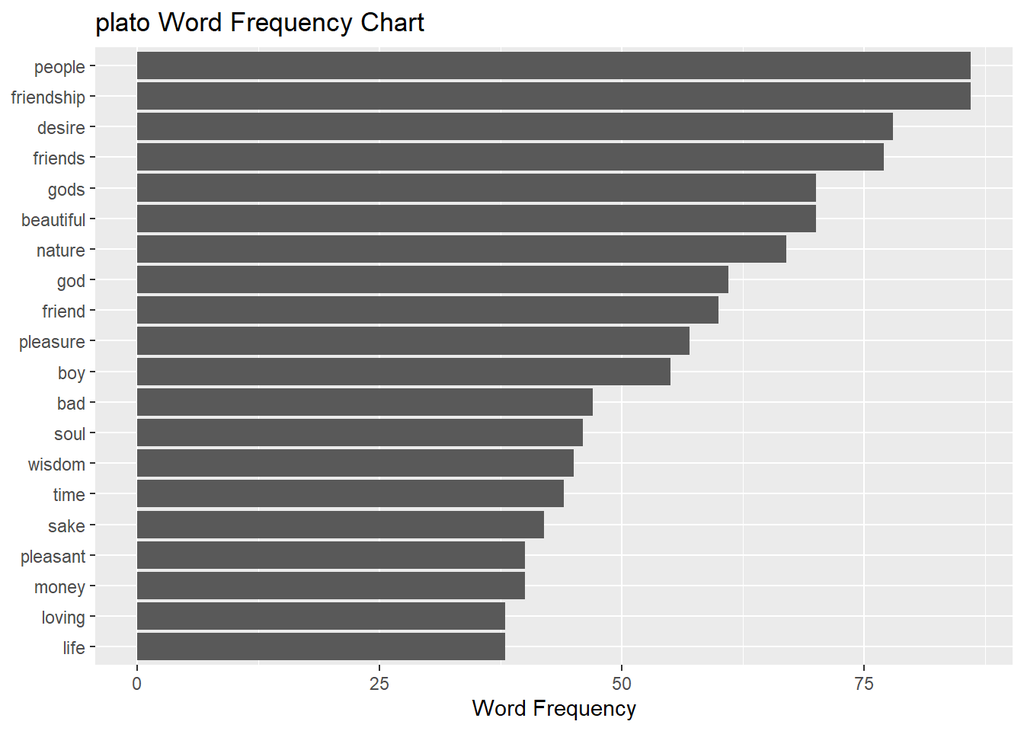

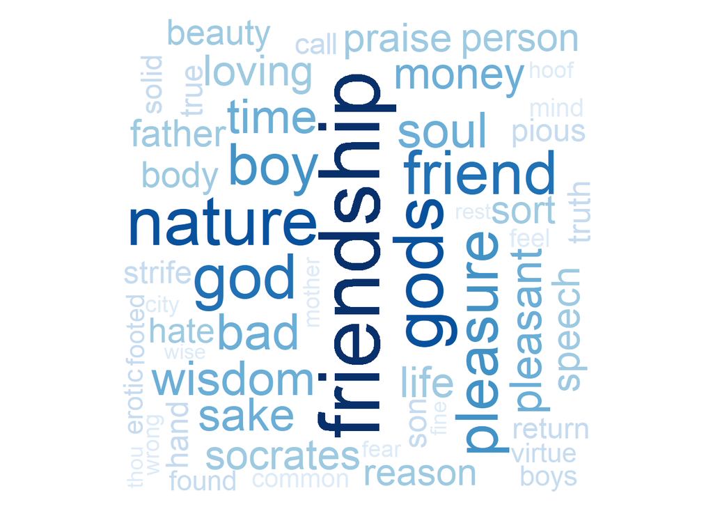

It can be indicated that the Mordern philosophy studied a lot about god. For them, love and hatred are antonyms, but love in general should be pleasure.

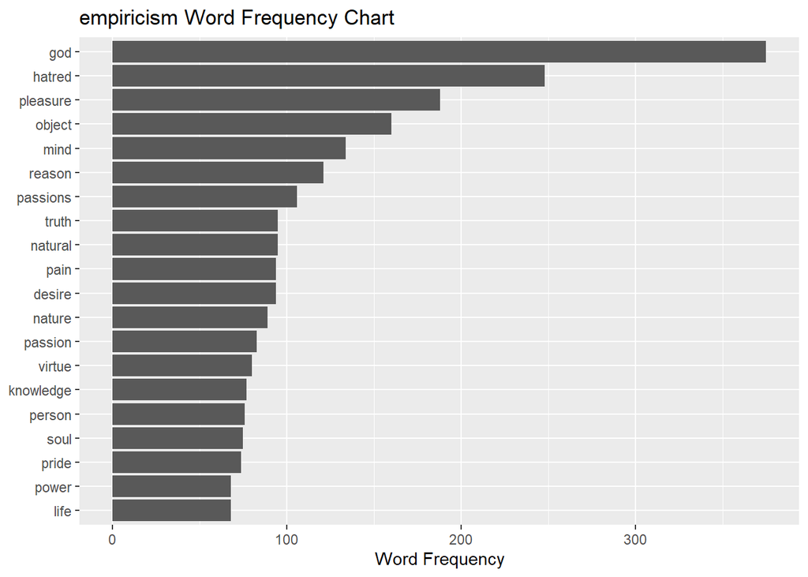

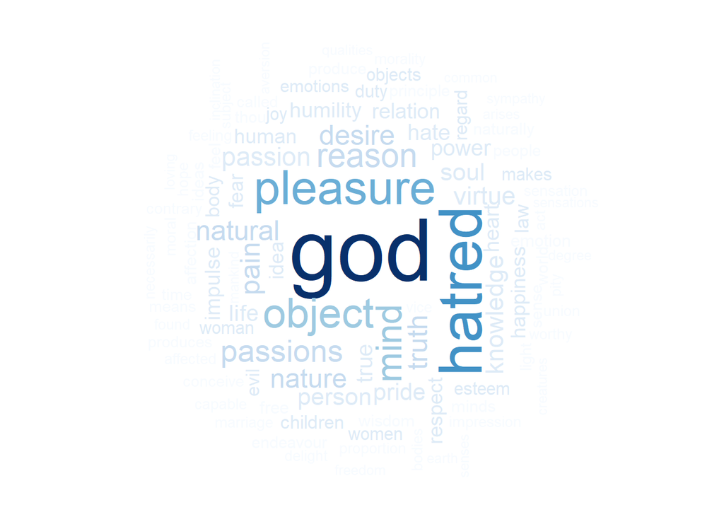

Feminism occupies a large part in the Contemporary philosophy in our dataset, and that's why we see the most frequent word about love is word like woman and husband. But anyway, we could suggests from the plots that love must be a vital part of life of people of different identities during the Contemporary philosophy.

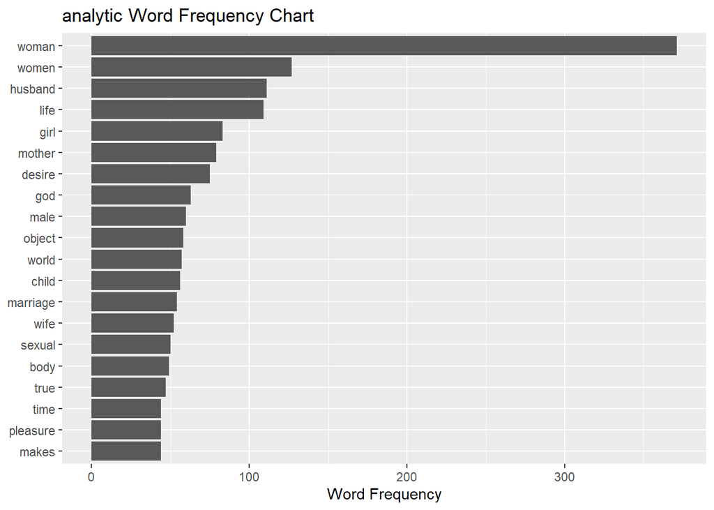

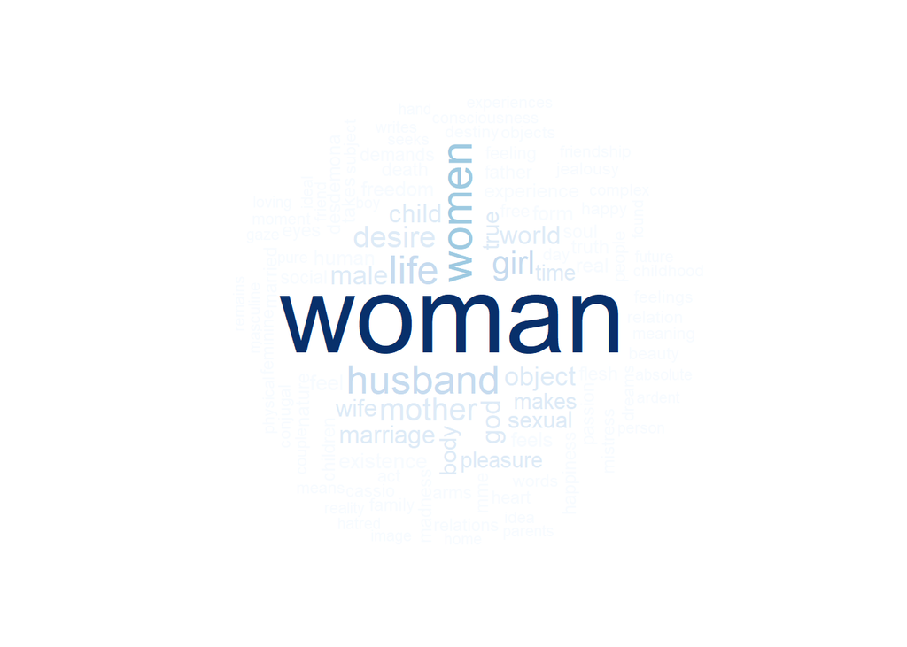

We could see from the above results that regarless of time period, philosophers are always interesting in studying about love. Whether you are from ancient or nowadays, love always plays an important role in our lives.

## IV. Obtain word frequency and word cloud of different schools

The word frequency chart and word cloud of different schools are consistent with each other, and we can do brief analysis based on them.

According to Aristotle philosophy, love is always talked along with friendship, which indicates that love and friendship may be a main topic for Aristotle philosophy, and in their opinion, love is a very pleasant thing.

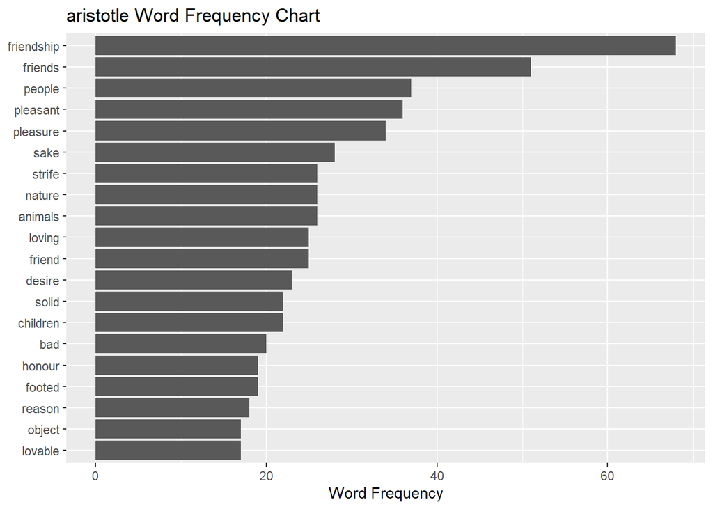

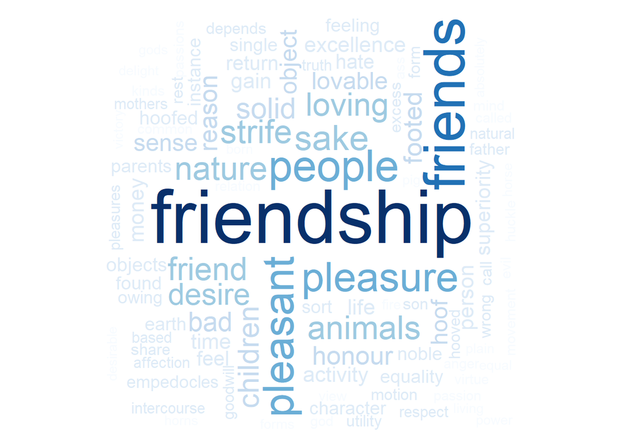

As for Plato, the result is consistent with its famous saying "love is a desire for beauty" and "The god of love lives in a state of need". It shows that love is a beautiful and desirable thing.

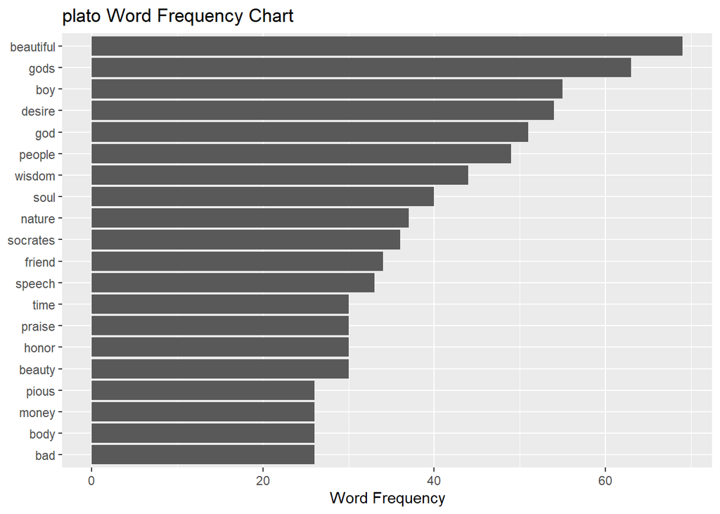

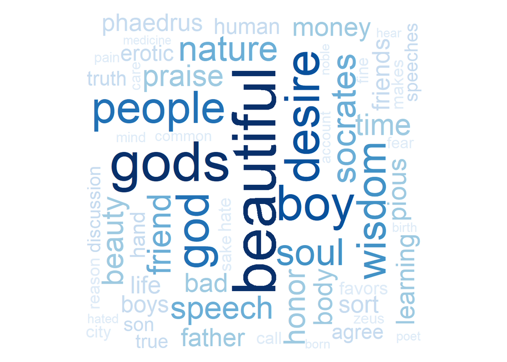

For Rationalism philosophy, god is always talked when mentioning love. And love is a object but also pleasant.

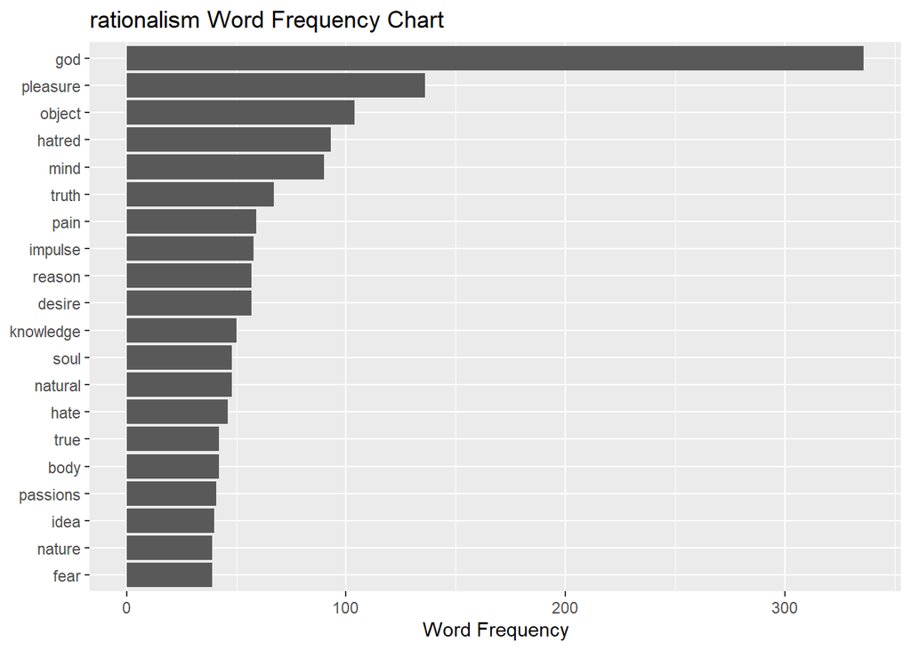

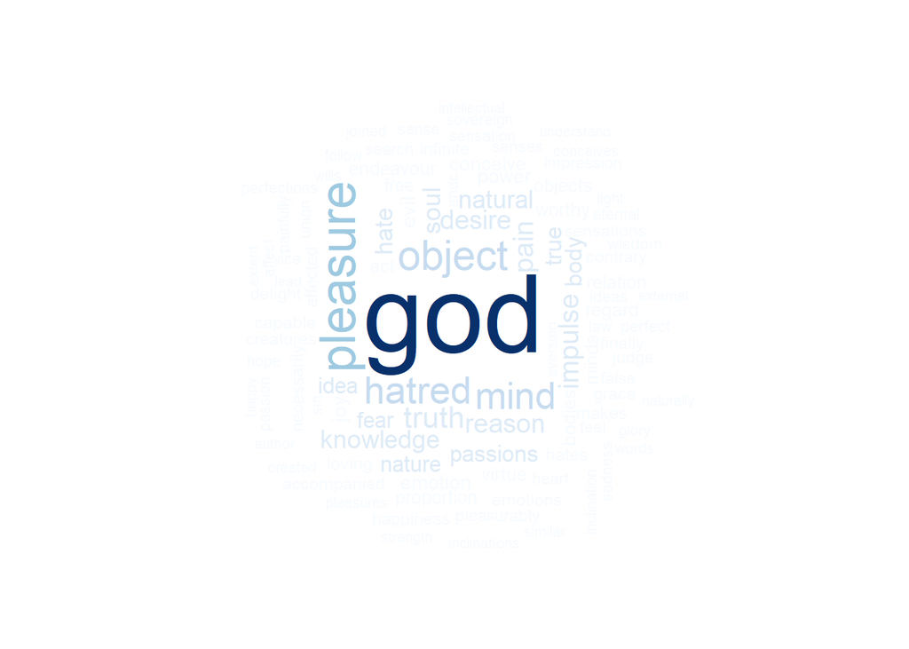

Nietzsche philosophy always mention "life" when talking about "love", indicating that love is a vital part of human life. But their attitude toward love could not be seen from the result.

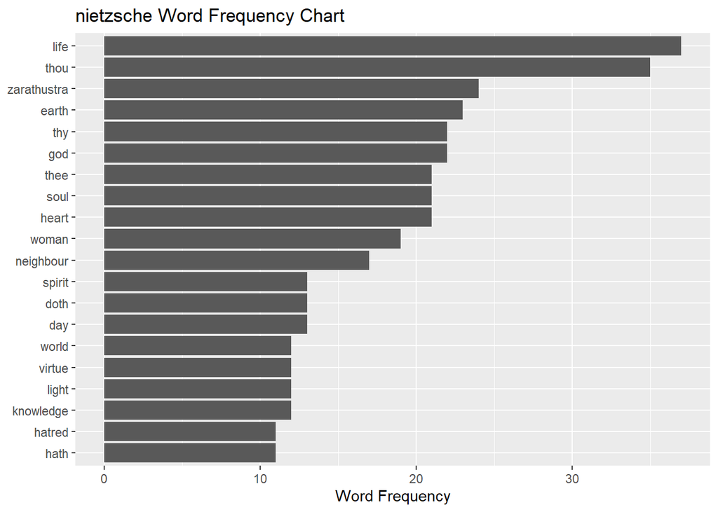

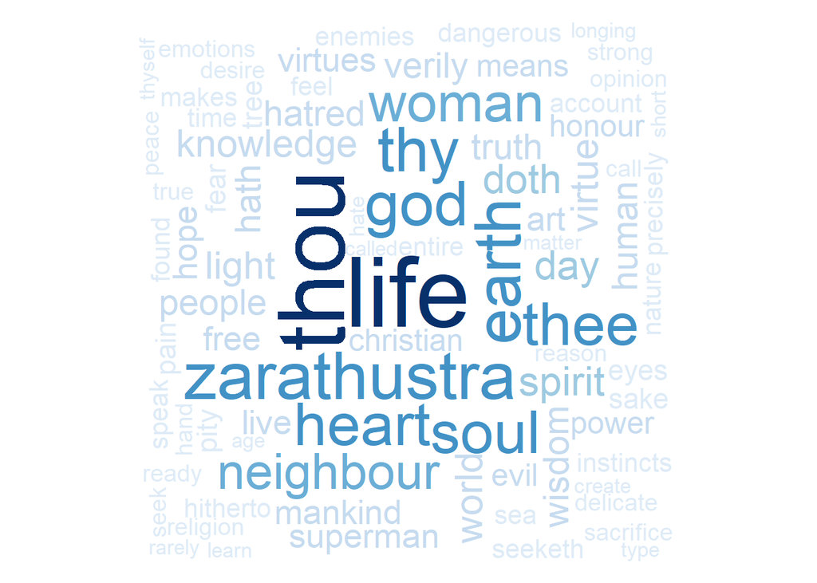

It is not surprsing at all that the most frequent word for Frminism philosophy is woman, and there are several words on the top list that express the identities of different people. We could see that no matter you are male or female, parent or children, feminists view love as vital part of life of all knids of people.

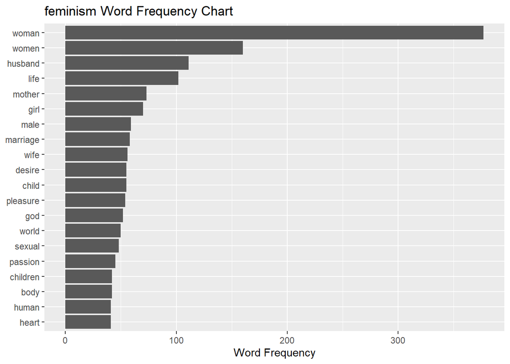

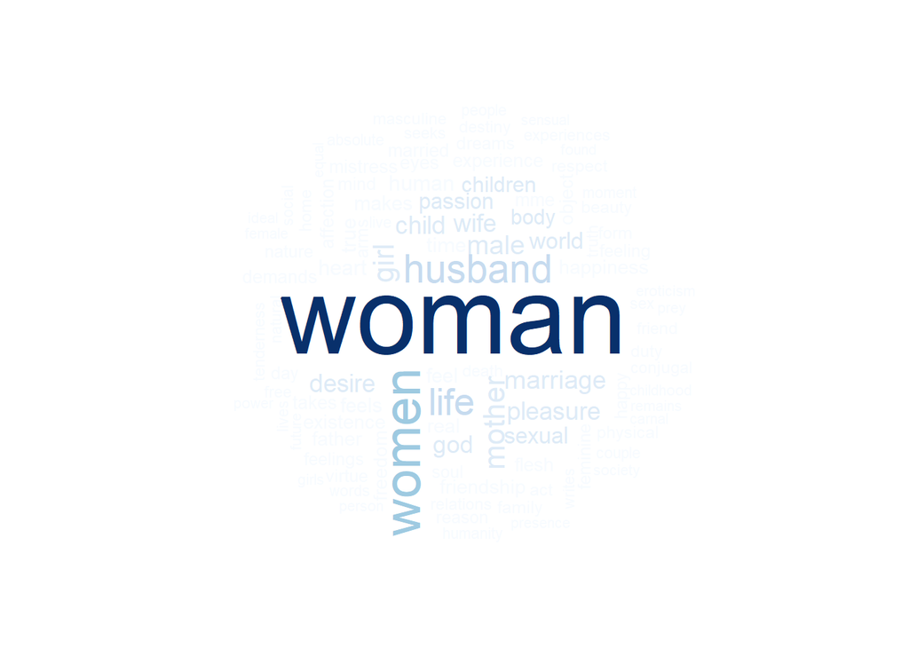

The above results suggests that although philosophers may have different focuse and opinion on the topic about love, love is an unavoidable part in everyone's life and most philosophers believe it brings people pleasure.

# Conclusion:

Regarless of time period and schools, philosophers are always interesting in studying about love. Whether you are from ancient or nowadays, love always plays a role in our lives.

Although philosophers may have different focuse and opinion on the topic about love, it is agreed by most philosophers from different schools and periods that love brings people pleasure.